# MSCA 37016 Advanced Linear Algebra for Machine Learning

© 2020 Danny Ng

# 1 Principal Component Analysis PCA

## 1.1 Data Points and Centering

- Create data matrix `X` of 1000 data points in 2-dimensional space i.e. 1000 rows and 2 columns. (Don’t worry about how.)

```r
# Create 1000 data points X
set.seed(1)
n <- 1000
mu <- c(8, -5)
C <- matrix(c(3, 1.5, 1.5, 1), 2, 2)
X <- rep(mu, each=n) + matrix(rnorm(n * 2), n, 2) %*% chol(C) # n-by-d
colnames(X) <- c('x1', 'x2')

head(X)
```

```
            x1        x2
[1,]  6.914950 -4.975042
[2,]  8.318080 -4.284994
[3,]  6.552649 -6.159064
[4,] 10.763107 -3.513081
[5,]  8.570724 -4.679940
[6,]  6.578907 -6.541871
```

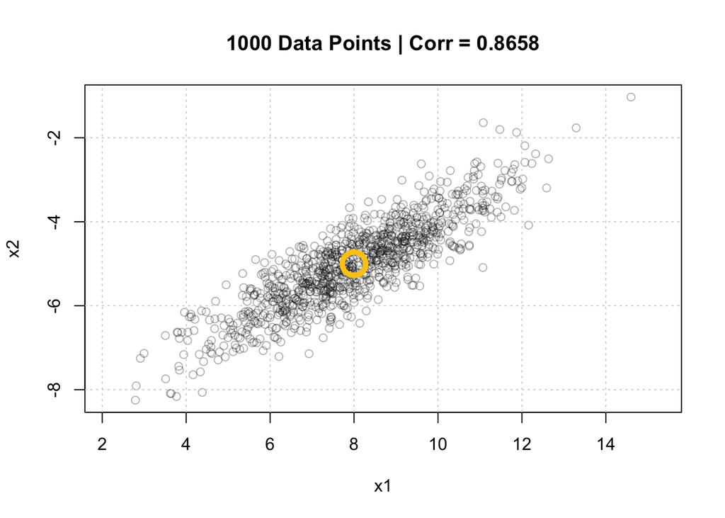

```r
# Plot data
plot(X[,1], X[,2], col=rgb(0, 0, 0, alpha=0.3), asp=1, xlab='x1', ylab='x2',
     main=paste(n, 'Data Points | Corr =', round(cor(X[,1], X[,2]), 4)))
grid()
points(mu[1], mu[2], col='#FFC90E', cex=3, lwd=5)
```

- Create centered data matrix `Xc`. Each column has mean 0.

```r
# Center the data
(mu <- colMeans(X))
```

```
       x1        x2
 7.979825 -5.018219
```

```r
Xc <- X - matrix(mu, nrow=n, ncol=2, byrow=TRUE)
# Xc <- scale(X, center=TRUE, scale=FALSE)
# attributes(Xc)$`scaled:center`

head(Xc)
```

```
             x1          x2
[1,] -1.0648747  0.04317617
[2,]  0.3382547  0.73322425
[3,] -1.4271760 -1.14084588
[4,]  2.7832826  1.50513804
[5,]  0.5908994  0.33827847
[6,] -1.4009178 -1.52365235
```

```r
colMeans(Xc) # Verify is 0
```

```
           x1            x2
-3.597123e-16 -3.330669e-17
```

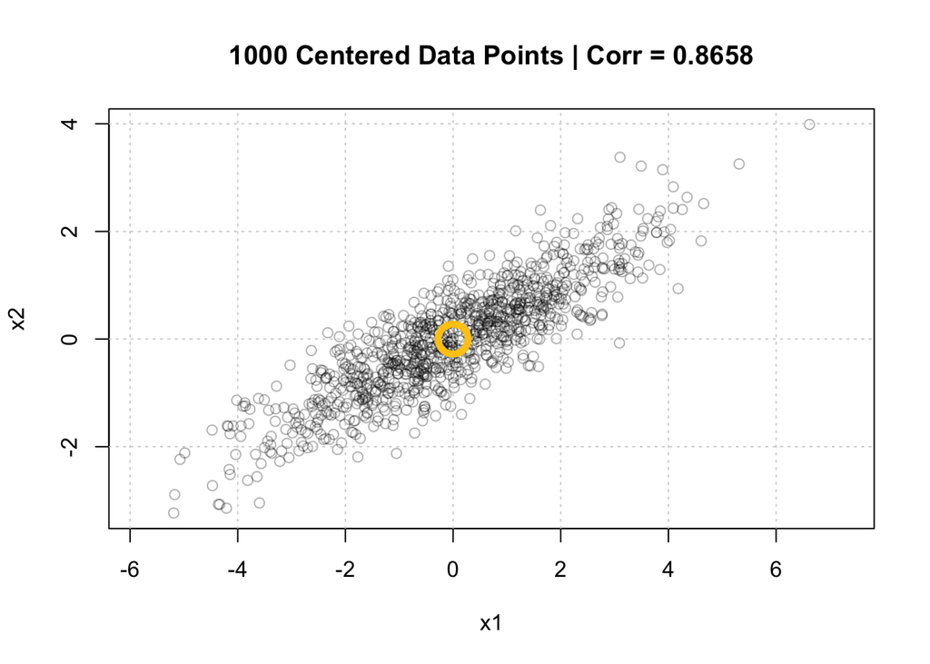

```r
# Plot centered data
plot(Xc[,1], Xc[,2], col=rgb(0, 0, 0, alpha=0.3), asp=1, xlab='x1', ylab='x2',
     main=paste(n, 'Centered Data Points | Corr =', round(cor(Xc[,1], Xc[,2]), 4)))
grid()
points(0, 0, col='#FFC90E', cex=3, lwd=5)
```

## 1.2 Major and Minor Axes of Data Ellipsoid?

- Scatter plot of the data point “cloud” usually looks like an ellipse with a major axis and a minor axis.
- Variation of the data is highest along the direction of the major axis.

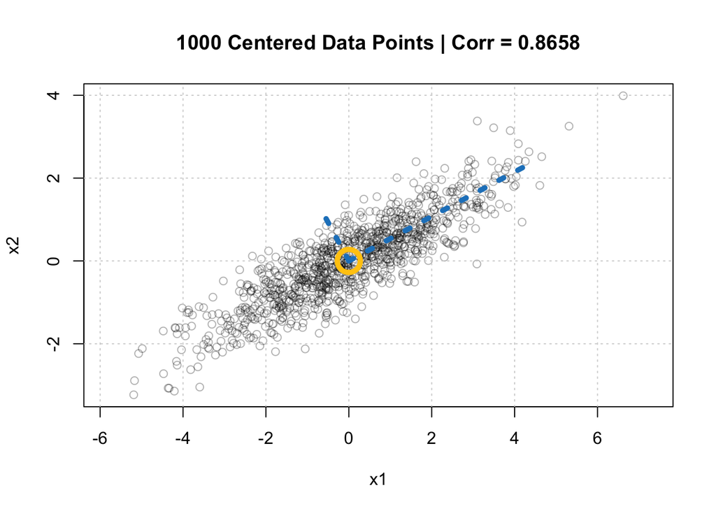

```r
v1 <- c(0.8808331, 0.4734270) # Unit vector of major axis
v2 <- c(-0.4734270, 0.8808331) # Unit vector of minor axis

# Plot axes of data ellipsoid
plot(Xc[,1], Xc[,2], col=rgb(0, 0, 0, alpha=0.3), asp=1, xlab='x1', ylab='x2',
     main=paste(n, 'Centered Data Points | Corr =', round(cor(Xc[,1], Xc[,2]), 4)))
grid()
lines(c(0, v1[1]) * 5, c(0, v1[2]) * 5, col='#2083C5', lwd=5, lty=3)
lines(c(0, v2[1]) * 1.5, c(0, v2[2]) * 1.5, col='#2083C5', lwd=5, lty=3)
points(0, 0, col='#FFC90E', cex=3, lwd=5)
```

## 1.3 Projection To Lower-Dimensional Space?

- If we wish to reduce the 2-dimensional data `Xc` into just 1-dimensional information, then it seems a good idea to project the data onto the major axis in order to retain the largest amount of variation in the data i.e. minimial loss of information.

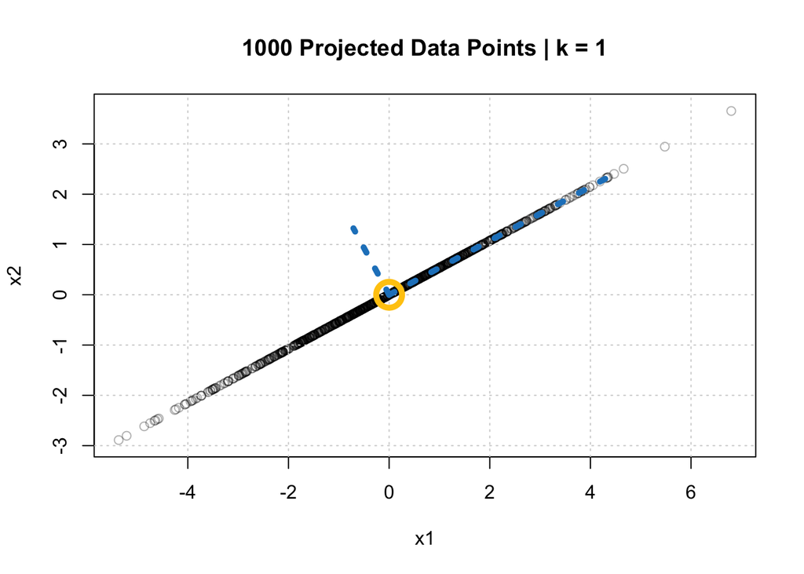

```r
# Orthogonal projection of each row of data in Xc onto v1
Xk <- (Xc %*% v1 / sum(v1 * v1)) %*% t(v1)

# Plot projected data
plot(Xk[,1], Xk[,2], col=rgb(0, 0, 0, alpha=0.3), asp=1, xlab='x1', ylab='x2',
     main=paste(n, 'Projected Data Points | k = 1'))
grid()
lines(c(0, 0.881 * 5), c(0, 0.473 * 5), col='#2083C5', lwd=5, lty=3) # Major axis
lines(c(0, -0.473 * 1.5), c(0, 0.881 * 1.5), col='#2083C5', lwd=5, lty=3) # Minor axis
points(0, 0, col='#FFC90E', cex=3, lwd=5)
```

## 1.4 Variance and Covariance Matrix

```r
# Centered data
head(Xc)
```

```
             x1          x2
[1,] -1.0648747  0.04317617
[2,]  0.3382547  0.73322425
[3,] -1.4271760 -1.14084588
[4,]  2.7832826  1.50513804
[5,]  0.5908994  0.33827847
[6,] -1.4009178 -1.52365235
```

```r
# Compute variance Var(X1) of 1st column
var(Xc[,1]) # Divided by n - 1 instead of n
```

```
[1] 3.213152
```

```r
sum(Xc[,1] ** 2) / (n - 1) # (norm of 1st column)^2 / (n - 1)
```

```
[1] 3.213152
```

```r
var(Xc[,1]) - sum(Xc[,1] ** 2) / (n - 1) # Verify same
```

```
[1] 0
```

```r
# Compute covariance Cov(X1,X2) between 1st and 2nd columns
cov(Xc[,1], Xc[,2]) # Divided by n - 1 instead of n
```

```
[1] 1.612543
```

```r
(Xc[,1] %*% Xc[,2]) / (n - 1) # (dot product) / (n - 1)
```

```
         [,1]
[1,] 1.612543
```

```r
cov(Xc[,1], Xc[,2]) - (Xc[,1] %*% Xc[,2]) / (n - 1) # Verify same
```

```
             [,1]
[1,] 2.220446e-16
```

```r
# Compute covariance matrix Cov(X) of data Xc
(C <- 1 / (n - 1) * t(Xc) %*% Xc)
```

```
         x1       x2
x1 3.213152 1.612543
x2 1.612543 1.079645
```

```r
cov(X) # C
```

```
         x1       x2
x1 3.213152 1.612543
x2 1.612543 1.079645
```

## 1.5 Overview

- In practice, instead of projecting the data onto the major axis directly, we do the following:

```
             x1          x2
[1,] -1.0648747  0.04317617
[2,]  0.3382547  0.73322425
[3,] -1.4271760 -1.14084588
[4,]  2.7832826  1.50513804
[5,]  0.5908994  0.33827847
[6,] -1.4009178 -1.52365235
```

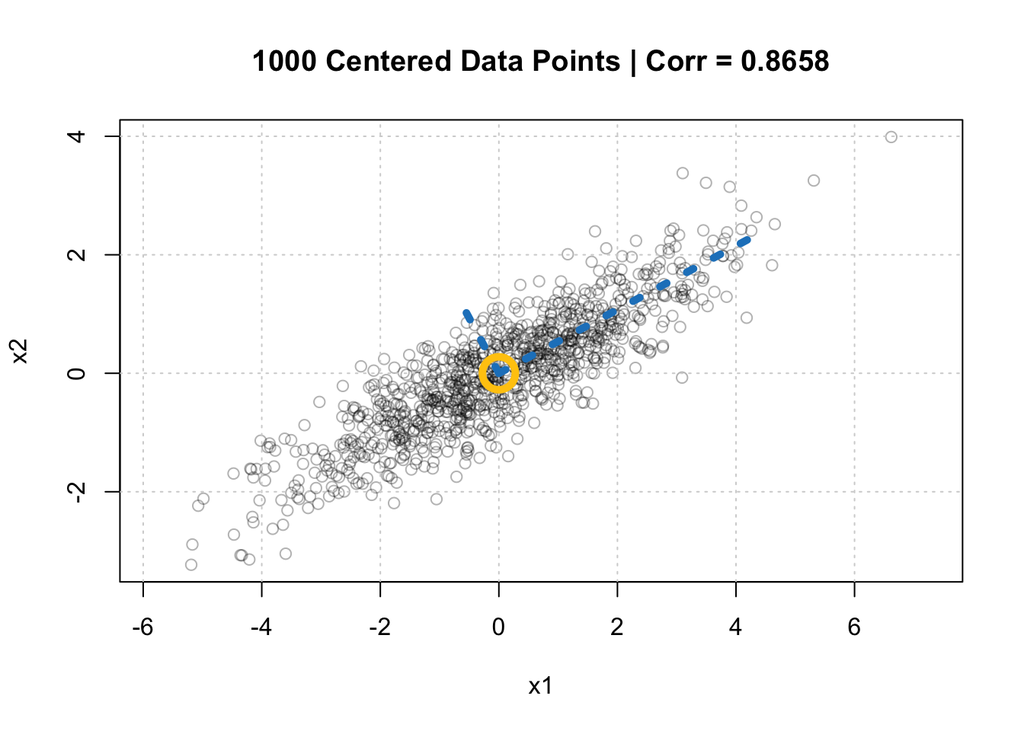

- Use an appropriate orthogonal matrix $Q\in\mathbb{R}^{d\times d}$ (from singular value decomposition SVD) to rotate the centered data `Xc` so it becomes axis-aligned.
- Mathematically, this transforms the data `Xc` from its original coordinates to another rotated coordinates system.
- Statistically, being “axis-aligned” means the $d$ columns of explanatory variables in the rotated data `Xr` are now **uncorrelated**. In other words, this rotation “de-correlates” the original data.

```
             v1           v2
[1,] -0.9175361  0.542171415
[2,]  0.6450741  0.485709261
[3,] -1.7972111 -0.329231143
[4,]  3.1641804  0.008094282
[5,]  0.6806339  0.018219152
[6,] -1.9553129 -0.678851131
```

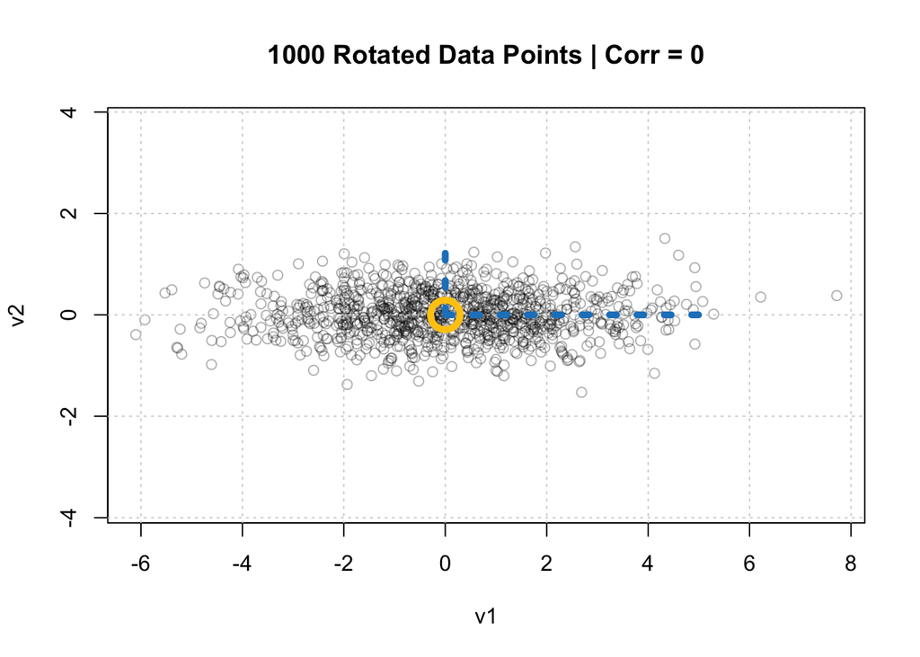

- Since the rotated data `Xr` is now axis-aligned, projection onto the first few dimensions is straight-forward.
- Simply keep the first (let’s say) $k$ coordinates that capture the highest variances and **truncate** / discard the remaining $d - k$ columns of variables in data `Xr`
- This $k$-dimensional data is the result of PCA dimension reduction.

```
             v1 v2
[1,] -0.9175361  0
[2,]  0.6450741  0
[3,] -1.7972111  0
[4,]  3.1641804  0
[5,]  0.6806339  0
[6,] -1.9553129  0
```

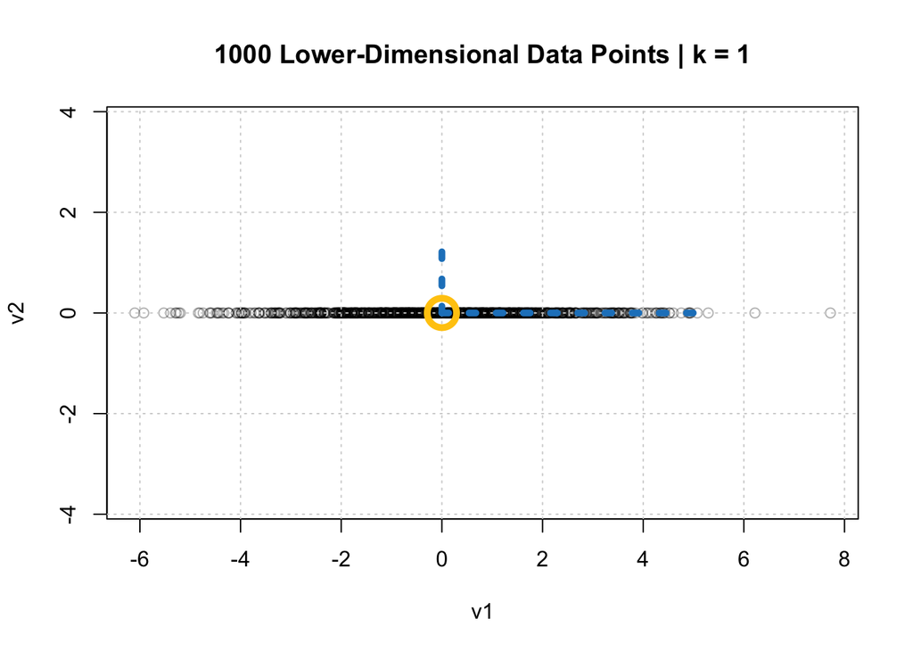

- (Optional) For visualization, we could un-rotate the lower $k$-dimensional data back to the original $d$-dimensional coordinates using the inverse transformation $Q^{-1}$ (which equals $Q^T$).
- However, in practice, we usually just use the reduced $k$-dimensional data above as input to a machine learning model.

```
             x1         x2
[1,] -0.8081961 -0.4343864
[2,]  0.5682026  0.3053955
[3,] -1.5830431 -0.8508483
[4,]  2.7871148  1.4980084
[5,]  0.5995249  0.3222305
[6,] -1.7223043 -0.9256979
```

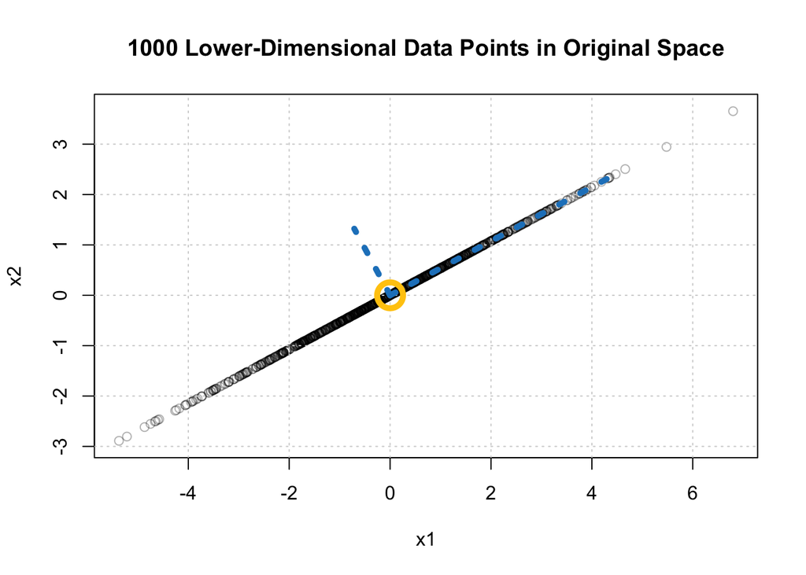

## 1.6 Singular Value Decomposition SVD

```r
# Compute SVD on centered data Xc
output <- svd(Xc)
U <- output$u # n-by-d
D <- output$d # d-tuple
V <- output$v # d-by-d

dim(U) # n-by-d
```

```
[1] 1000    2
```

```r
head(U)
```

```
            [,1]          [,2]
[1,] -0.01437202 -0.0371726842
[2,]  0.01010426 -0.0333014891
[3,] -0.02815101  0.0225729402
[4,]  0.04956283 -0.0005549591
[5,]  0.01066126 -0.0012491512
[6,] -0.03062747  0.0465437957
```

```r
c(sum(U[,1] ** 2), sum(U[,2] ** 2), sum(U[,1] * U[,2])) # Verify columns of U are orthonormal
```

```
[1] 1.000000e+00 1.000000e+00 1.986627e-16
```

```r
D # Singular values sigma_i
```

```
[1] 63.84181 14.58521
```

```r
V
```

```
          [,1]       [,2]
[1,] 0.8808331  0.4734270
[2,] 0.4734270 -0.8808331
```

```r
t(V) %*% V # Verify V is orthogonal matrix
```

```
     [,1] [,2]
[1,]    1    0
[2,]    0    1
```

```r
max(abs(Xc - U %*% diag(D) %*% t(V))) # Verify Xc = U * D * V^T
```

```
[1] 1.454392e-14
```

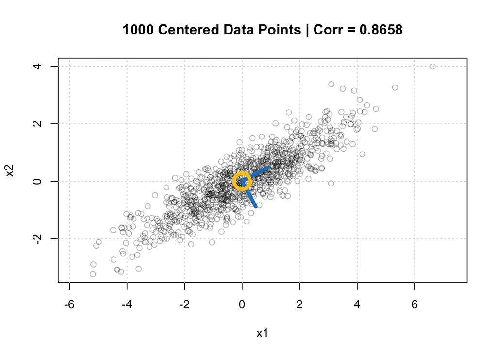

```r
# Plot axes of data ellipsoid i.e. columns of V
plot(Xc[,1], Xc[,2], col=rgb(0, 0, 0, alpha=0.3), asp=1, xlab='x1', ylab='x2',
     main=paste(n, 'Centered Data Points | Corr =', round(cor(Xc[,1], Xc[,2]), 4)))
grid()
lines(c(0, V[1,1]), c(0, V[2,1]), col='#2083C5', lwd=5, lty=1)
lines(c(0, V[1,2]), c(0, V[2,2]), col='#2083C5', lwd=5, lty=1)
points(0, 0, col='#FFC90E', cex=3, lwd=5)
```

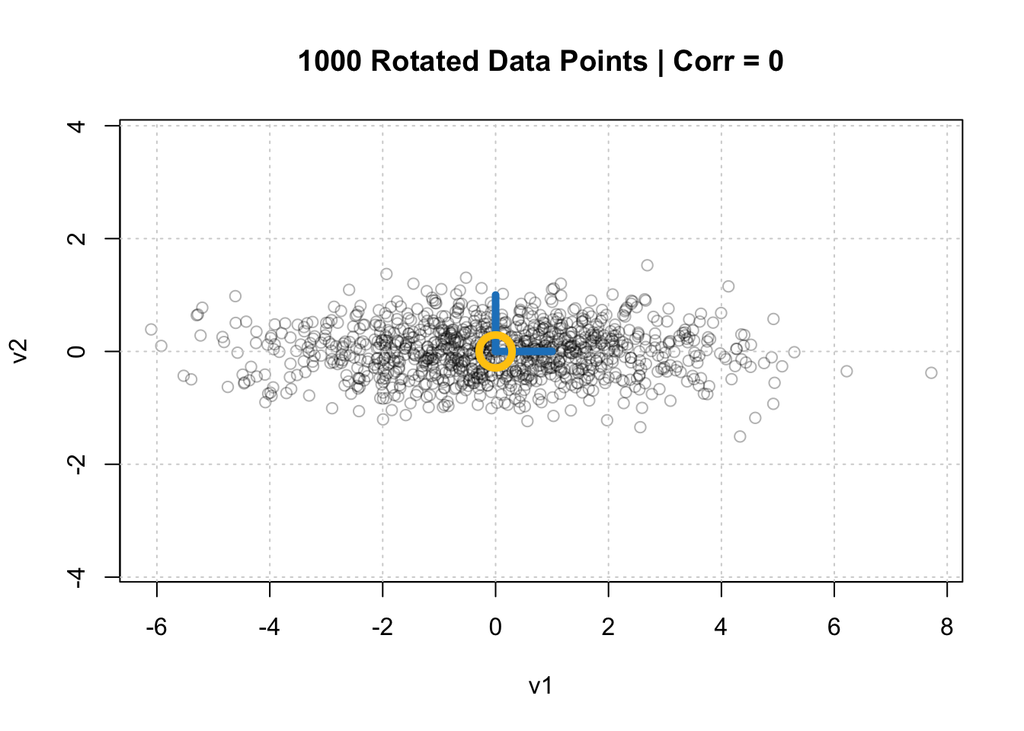

```r
# Rotate the centered data using V
Xr <- Xc %*% V # Same as U * D

# Plot the centered and rotated data
plot(Xr[,1], Xr[,2], col=rgb(0, 0, 0, alpha=0.3), asp=1, xlab='v1', ylab='v2',
     main=paste(n, 'Rotated Data Points | Corr =', round(cor(Xr[,1], Xr[,2]), 4)))
grid()
lines(c(0, 1), c(0, 0), col='#2083C5', lwd=5, lty=1)
lines(c(0, 0), c(0, 1), col='#2083C5', lwd=5, lty=1)
points(0, 0, col='#FFC90E', cex=3, lwd=5)
```

## 1.7 prcomp()

```r
output <- prcomp(X) # Perform svd() after centering X

output$center # mu
```

```
       x1        x2
 7.979825 -5.018219
```

```r
output$rotation # V
```

```
         PC1        PC2
x1 0.8808331  0.4734270
x2 0.4734270 -0.8808331
```

```r
head(output$x) # Xr
```

```
            PC1          PC2
[1,] -0.9175360 -0.542171420
[2,]  0.6450741 -0.485709225
[3,] -1.7972111  0.329231082
[4,]  3.1641803 -0.008094196
[5,]  0.6806339 -0.018219133
[6,] -1.9553128  0.678851053
```

```r
output$sdev # D / sqrt(n - 1)
```

```
[1] 2.0198654 0.4614556
```

# 2 Eigenvalue and Eigenvector

```r
A <- matrix(c(2, 3, 4, -2), 2, 2)

A
```

```
     [,1] [,2]
[1,]    2    4
[2,]    3   -2
```

```r
eigen(A)
```

```
eigen() decomposition
$values
[1]  4 -4

$vectors
          [,1]       [,2]
[1,] 0.8944272 -0.5547002
[2,] 0.4472136  0.8320503
```

```r
lambda <- eigen(A)$values
V <- eigen(A)$vectors

A %*% V[,1] - lambda[1] * V[,1] # Verify same
```

```
             [,1]
[1,] 0.000000e+00
[2,] 2.220446e-16
```

```r
A %*% V[,2] - lambda[2] * V[,2] # Verify same
```

```
              [,1]
[1,] -4.440892e-16
[2,] -4.440892e-16
```

```r
c(sum(V[,1] * V[,1]), sum(V[,2] * V[,2]), sum(V[,1] * V[,2])) # Verify orthonormal
```

```
[1]  1.0000000  1.0000000 -0.1240347
```

```r
D <- diag(lambda)
V %*% D %*% solve(V) # Verify same as A
```

```
     [,1] [,2]
[1,]    2    4
[2,]    3   -2
```

```r
det(A) - prod(lambda) # Verify det(A) = prod(eigenvalues)
```

```
[1] -7.105427e-15
```

```r
sum(diag(A)) - sum(lambda) # Verify tr(A) = sum(eigenvalues)
```

```
[1] 0
```

```r
A <- matrix(c(2, 0, 3, 2), 2, 2) # Not diagonalizable

A
```

```
     [,1] [,2]
[1,]    2    3
[2,]    0    2
```

```r
eigen(A)
```

```
eigen() decomposition
$values
[1] 2 2

$vectors
     [,1]          [,2]
[1,]    1 -1.000000e+00
[2,]    0  1.480297e-16
```

```r
A <- matrix(c(0, -1, 1, 0), 2, 2) # No real eigenvalue

A
```

```
     [,1] [,2]
[1,]    0    1
[2,]   -1    0
```

```r
eigen(A)
```

```
eigen() decomposition
$values
[1] 0+1i 0-1i

$vectors
                     [,1]                 [,2]
[1,] 0.7071068+0.0000000i 0.7071068+0.0000000i
[2,] 0.0000000+0.7071068i 0.0000000-0.7071068i
```

```r
A <- matrix(c(4, -2, 1, -2, 1, 2, 1, 2, 4), 3, 3) # Some symmetric matrix

A
```

```
     [,1] [,2] [,3]
[1,]    4   -2    1
[2,]   -2    1    2
[3,]    1    2    4
```

```r
eigen(A)
```

```
eigen() decomposition
$values
[1]  5  5 -1

$vectors
          [,1]       [,2]       [,3]
[1,] 0.0000000  0.9128709  0.4082483
[2,] 0.4472136 -0.3651484  0.8164966
[3,] 0.8944272  0.1825742 -0.4082483
```

```r
Q <- eigen(A)$vectors # Eigenvectors

t(Q) %*% Q # Verify orthogonal matrix
```

```
              [,1]         [,2]          [,3]
[1,]  1.000000e+00 0.000000e+00 -5.551115e-17
[2,]  0.000000e+00 1.000000e+00  9.714451e-17
[3,] -5.551115e-17 9.714451e-17  1.000000e+00
```

```r
det(Q)
```

```
[1] 1
```

## 2.1 PCA via Cov(X)

```r
# Covariance matrix Cov(X) of data Xc
C
```

```
         x1       x2
x1 3.213152 1.612543
x2 1.612543 1.079645
```

```r
# Perform eigen-decomposition on C
eigen(C)
```

```
eigen() decomposition
$values
[1] 4.0798561 0.2129413

$vectors
           [,1]       [,2]
[1,] -0.8808331  0.4734270
[2,] -0.4734270 -0.8808331
```

```r
Q <- eigen(C)$vectors
lambda <- eigen(C)$values

Q %*% diag(lambda) %*% t(Q) # Verify same as C
```

```
         [,1]     [,2]
[1,] 3.213152 1.612543
[2,] 1.612543 1.079645
```

```r
Q # Principal components using Cov(X)
```

```
           [,1]       [,2]
[1,] -0.8808331  0.4734270
[2,] -0.4734270 -0.8808331
```

```r
V # Verify principal components using SVD on Xc previously is same as Q (up to sign)
```

```
          [,1]       [,2]
[1,] 0.8944272 -0.5547002
[2,] 0.4472136  0.8320503
```

```r
# Percentage of variance explained along each principal component direction
lambda / sum(lambda)
```

```
[1] 0.95039568 0.04960432
```

## 2.2 princomp()

```r
output <- princomp(X) # Perform eigen() on covariance matrix Cov(X) of X

output$center # mu
```

```
       x1        x2
 7.979825 -5.018219
```

```r
output$loadings # Q
```

```
Loadings:
   Comp.1 Comp.2
x1  0.881  0.473
x2  0.473 -0.881

               Comp.1 Comp.2
SS loadings       1.0    1.0
Proportion Var    0.5    0.5
Cumulative Var    0.5    1.0
```

```r
output$sdev # sqrt((n - 1) / n * D)
```

```
   Comp.1    Comp.2
2.0188552 0.4612248
```

```r
head(output$scores) # Xr
```

```
         Comp.1       Comp.2
[1,] -0.9175360 -0.542171420
[2,]  0.6450741 -0.485709225
[3,] -1.7972111  0.329231082
[4,]  3.1641803 -0.008094196
[5,]  0.6806339 -0.018219133
[6,] -1.9553128  0.678851053
```